# Example of the SuperCell pipeline

## Map each metacell to a particular cell line

We now assign each metcell to a particular cell line based on the cell line data, for this, we use function `supercell_assign()`. By default, this function assign each metacell to a cluster with the largest Jaccard coefficient to avoid biases towards very rare or very abundant clusters. Alternatively, assigmnent can be performed using relative (may cause biase towards very small populations) or absolute (may cause biase towards large populations) abundance with `method = "relative"` or `method = "absolute"`, respectively.

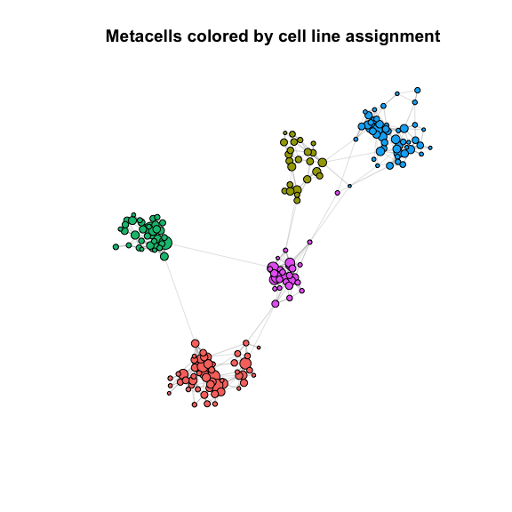

```r
SC$cell_line <- supercell_assign(clusters = cell.meta, # single-cell assigment to cell lines (clusters)
                                 supercell_membership = SC$membership, # single-cell assignment to metacells
                                 method = "jaccard")


seed <- 1 # seed for network plotting

# plot network of metacells colored by cell line assignment
supercell_plot(SC$graph.supercells,
               group = SC$cell_line,
               seed = seed,
               main = "Metacells colored by cell line assignment")
```

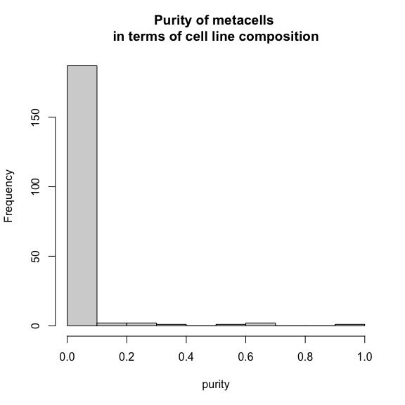

```r
# compute purity of metacells in terms of cell line composition
purity <- supercell_purity(clusters = cell.meta,
                           supercell_membership = SC$membership, method = 'entropy')
hist(purity, main = "Purity of metacells \nin terms of cell line composition")
```

Some options to plot networks of metacells

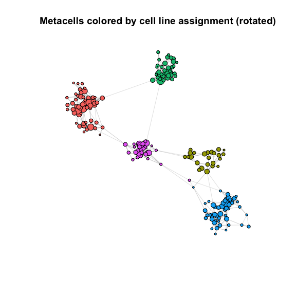

```r
## rotate network to be more consistent with the single-cell one
supercell_plot(SC$graph.supercells,
               group = SC$cell_line,
               seed = seed,
               alpha = -pi/2,
               main  = "Metacells colored by cell line assignment (rotated)")
```

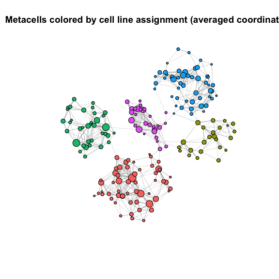

```r
## alternatively, any layout can be provided as 2xN numerical matrix, where N is number of nodes (cells)

## Let's plot metacell network using the layout of the single-cell network:
## 1) get single-cell network layout
my.lay.sc <- igraph::layout_components(SC$graph.singlecell)

## 2) compute metacell network layout averaging coordinates withing metacells
my.lay.SC <- Matrix::t(supercell_GE(ge = t(my.lay.sc), groups = SC$membership))

## 3) provide layout with the parameter $lay$
supercell_plot(SC$graph.supercells,
               group = SC$cell_line,
               lay = my.lay.SC,
               main  = "Metacells colored by cell line assignment (averaged coordinates)")
```

## Cluster metacell data

```r
#dimensionality reduction
SC.PCA         <- supercell_prcomp(Matrix::t(SC.GE), # metacell gene exptression matrix
                                   genes.use = SC$genes.use, # genes used for the coarse-graining, but any set can be provided
                                   supercell_size = SC$supercell_size, # sample-weighted pca
                                   k = 20)
## compute distance
D              <- dist(SC.PCA$x)

## cluster metacells
SC.clusters    <- supercell_cluster(D = D, k = 5, supercell_size = SC$supercell_size)
SC$clustering  <- SC.clusters$clustering
```

## Map clusters of metacells to cell lines

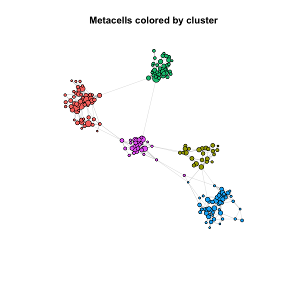

```r
## mapping metacell cluster to cell line
map.cluster.to.cell.line    <- supercell_assign(supercell_membership = SC$clustering, clusters  = SC$cell_line)
## clustering as cell line
SC$clustering_reordered     <- map.cluster.to.cell.line[SC$clustering]

supercell_plot(SC$graph.supercells,
               group = SC$clustering_reordered,
               seed = seed,
               alpha = -pi/2,
               main = "Metacells colored by cluster")
```

## Differential expression analysis of clustered metacell data

```r
markers.all.positive <- supercell_FindAllMarkers(ge = SC.GE, # metacell gene expression matrix
                                                 supercell_size = SC$supercell_size, # size of metacell for sample-weighted method
                                                 clusters = SC$clustering_reordered, # clustering
                                                 logfc.threshold = 1, # mininum log fold-change
                                                 only.pos = T) # keep only upregulated genes
markers.all.positive$H1975[1:20,]
```

```
#>         p.value adj.p.value     pct.1     pct.2    logFC  w.mean.1   w.mean.2
#> DHRS2         0           0 1.0000000 0.8279230 4.091797 3.6237875 0.10054192
#> MT1E          0           0 1.0000000 0.9413962 3.686582 4.6560576 0.69254917
#> PEG10         0           0 1.0000000 0.9652399 2.564663 3.2359195 0.89548751
#> LGALS1        0           0 1.0000000 1.0000000 2.394249 6.5798440 4.00039835
#> S100A2        0           0 1.0000000 0.9942545 2.338876 3.1041134 1.24595811
#> ZNF880        0           0 1.0000000 0.5955185 1.821237 1.6675772 0.08666412
#> MT2A          0           0 1.0000000 1.0000000 1.724771 6.3843539 4.12274024
#> CT45A2        0           0 1.0000000 0.6153404 1.684419 1.7640705 0.27318252
#> XAGE1B        0           0 1.0000000 1.0000000 1.669853 6.5436587 3.66859782
#> HSPB1         0           0 1.0000000 1.0000000 1.645122 5.5983707 3.87890578
#> PRDX2         0           0 1.0000000 0.9494398 1.638760 3.4980150 1.33455473
#> IFI27         0           0 1.0000000 0.9462798 1.636429 3.5275622 1.32877161
#> MT1P1         0           0 1.0000000 0.9988509 1.550382 3.2663495 1.50666087
#> TMEM134       0           0 1.0000000 0.9988509 1.508863 2.4398008 1.01156248
#> TNNT1         0           0 1.0000000 0.9844872 1.482153 3.2983849 1.63217280
#> XAGE1A        0           0 1.0000000 0.9750072 1.458697 2.8883699 1.06459003
#> MT2P1         0           0 1.0000000 0.9925309 1.457833 2.7769310 1.18613463
#> DMKN          0           0 1.0000000 0.9821890 1.455548 2.6011521 0.83344367
#> CAV1          0           0 1.0000000 1.0000000 1.388689 4.1486580 2.37528254
#> MGP           0           0 0.9427918 0.2071244 1.365311 0.6735631 0.01058892
```

## Some additional plotting options

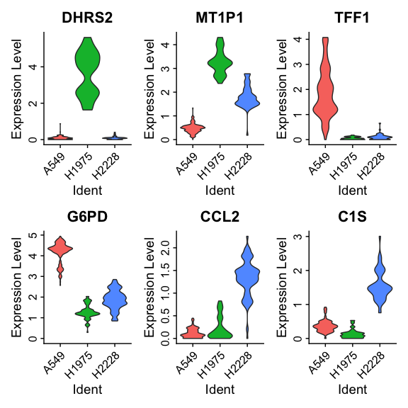

```r
genes.to.plot <- c("DHRS2", "MT1P1", "TFF1", "G6PD", "CCL2", "C1S")

supercell_VlnPlot(ge = SC.GE,
                  supercell_size = SC$supercell_size,
                  clusters = SC$clustering_reordered,
                  features = genes.to.plot,
                  idents = c("H1975", "H2228", "A549"),
                  ncol = 3)
```

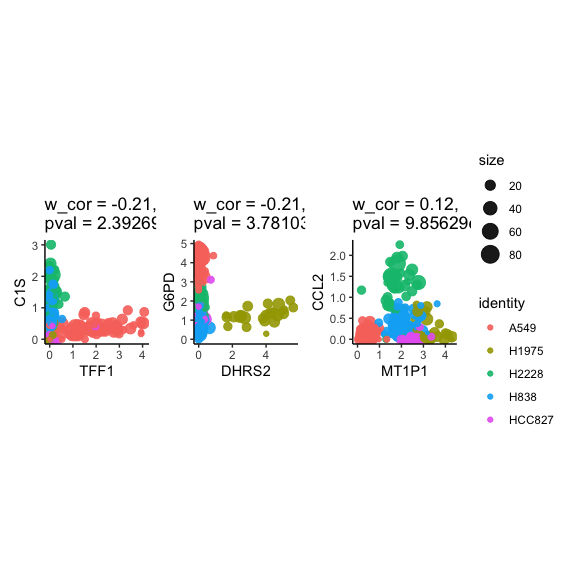

```
#>
#> $w.cor
#> $w.cor$TFF1_C1S
#> [1] -0.2127742
#>
#> $w.cor$DHRS2_G6PD
#> [1] -0.2069167
#>
#> $w.cor$MT1P1_CCL2
#> [1] 0.1232393
#>
#>
#> $w.pval
#> $w.pval$TFF1_C1S
#> [1] 2.392685e-41
#>
#> $w.pval$DHRS2_G6PD
#> [1] 3.781028e-39
#>
#> $w.pval$MT1P1_CCL2
#> [1] 9.856287e-15
```

```r
supercell_GeneGenePlot(ge = SC.GE,
                       gene_x = genes.to.plot[1:3],
                       gene_y = genes.to.plot[4:6],
                       supercell_size = SC$supercell_size,
                       clusters = SC$clustering_reordered,)
```

### SuperCell graining level can be quickly chaged with `supercell_rescale()` function

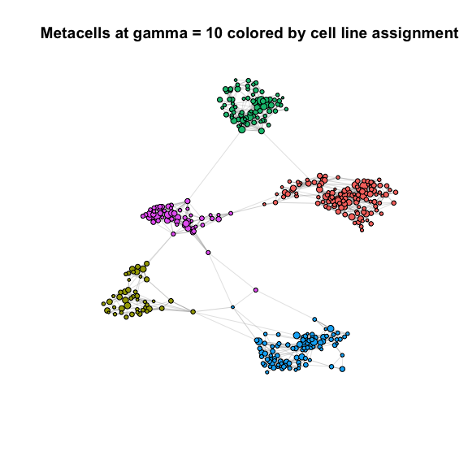

```r
SC10 <- supercell_rescale(SC, gamma = 10)

SC10$cell_line <- supercell_assign(clusters = cell.meta, # single-cell assigment to cell lines (clusters)
                                 supercell_membership = SC10$membership, # single-cell assignment to metacells
                                 method = "jaccard")

supercell_plot(SC10$graph.supercells,
               group = SC10$cell_line,
               seed = 1,
               main  = "Metacells at gamma = 10 colored by cell line assignment")
```

```r
### don't forget to recompute metacell gene expression matrix for a new grainig level with
# GE10 <- supercell_GE(GE, SC10$membership)
### if you are going to perform downstream analyses at the new graining level
```

### P.S.: SuperCell to [Seurat](https://cran.r-project.org/web/packages/Seurat/index.html) object

In case you want to perform other analyses available with Seurat package, we can convert SuperCell to [Seurat](https://cran.r-project.org/web/packages/Seurat/index.html) object with function `supercell_2_Seurat()` or to [SingleCellExperiment](https://bioconductor.org/packages/release/bioc/html/SingleCellExperiment.html) object with function ‘supercell_2_sce()’. Let consider a Seurat example.

```r
#install.packages("Seurat")
library(Seurat)
m.seurat <- supercell_2_Seurat(SC.GE = SC.GE, SC = SC, fields = c("cell_line", "clustering", "clustering_reordered"))
```

```
#> [1] "Done: NormalizeData"
#> [1] "Doing: data to normalized data"
#> [1] "Doing: weighted scaling"
#> [1] "Done: weighted scaling"
```

Note: since metacells have different size (consist of different number of cells), we apply sample-weighted algorithms at most af the steps of the downstream analyses. Thus, when coercing SuperCell to Seurat, we replaced PCA, saling and kNN graph of Seurat object with those obtained applying sample-weighted version of PCA, scaling or SuperCell graph (i.e., metacell network), respectively. If you then again apply `RunPCA`, `ScaleData`, or `FindNeighbors`, the result will be rewritten, but you will be able to access them with `Embeddings(m.seurat, reduction = "pca_weigted")`, `m.seurat@assays$RNA@misc[["scale.data.weighted"]]`, or `m.seurat@graphs$RNA_super_cells`, respectively.

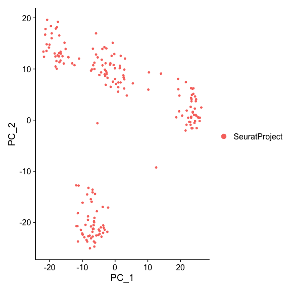

```r
PCAPlot(m.seurat)
```

```r
### cluster SuperCell network (unweighted clustering)
m.seurat <- FindClusters(m.seurat, graph.name = "RNA_nn") # now RNA_nn is metacell network
```

```
#> Modularity Optimizer version 1.3.0 by Ludo Waltman and Nees Jan van Eck
#>
#> Number of nodes: 196
#> Number of edges: 703
#>
#> Running Louvain algorithm...
#> Maximum modularity in 10 random starts: 0.8322
#> Number of communities: 7
#> Elapsed time: 0 seconds
```

```r
m.seurat <- FindNeighbors(m.seurat, verbose = FALSE)  # RNA_nn has been replaced with kNN graph of metacell (unweigted)
m.seurat <- FindClusters(m.seurat, graph.name = "RNA_nn")
```

```
#> Modularity Optimizer version 1.3.0 by Ludo Waltman and Nees Jan van Eck
#>
#> Number of nodes: 196
#> Number of edges: 2010
#>
#> Running Louvain algorithm...
#> Maximum modularity in 10 random starts: 0.7908
#> Number of communities: 5
#> Elapsed time: 0 seconds
```